# Data Translation Assignment

Kyle Bailey, Ryan Cowles, Joshua Jayandran, Samuel Suk, George Thiss, and Octavian Tofoleanu

[output not shown]

Introduction:

Our initial exploration of the data showed Covid had a strong effect on unemployment. We plotted the unemployment rate (calculated by taking the ratio of those employed vs unemployed found within the data) over time. We saw a sharp jump discontinuity in April of 2020 with a nearly 9% increase in unemployment following our defined start of Covid. Both our linear and polynomial models of the graphs supported this. Given this, we choose to create various models to analyze different factors’ effect on unemployment in a post-Covid world. Our regression analyses primarily focused on the variables we felt would impact unemployment like employment sector, region, education level, and race.

Methodology:

We are using regression discontinuity analysis because we want to observe the effect of Covid on employment across a two year period. Discontinuity works best because we want to know the short-term effect of Covid. Covid had a universal impact on employees of all industries, so through the following regressions, we are exploring how different workers were affected. First we observe how workers in the retail industry fared past the Covid cutoff. Following retail, we see how the industry itself compares to all other industries. Our last series of regressions observed how the unemployment rate changed for month-based groups along education and then total annual household income controls. We grouped income levels between those below the national median and those above. Another reason why RD works is because it pulls helpful and specific estimated treatment effects both immediately after the cut off month, and the remaining months of 2020. Adding additional controls like industry, geographic region, education level, and race allow us to compare the various effects Covid on different groups with regards to the unemployment rate. We define unemployment rate by the number employed and unemployed per month from the IPUMs data. We also have to recognize some generalizability – Covid and its associated lockdowns were not a one time effect, it was a prolonged occurrence over the coming two years, having a simultaneous impact on health which could affect employment status, as well as the economy vis-a-vis the state mandated closures of businesses. The best we can do working around this historic reality is by narrowing our study to just the immediate effect of Covid on observed workers with regards to their employment status which we transformed into unemployment rates per month. Additionally, not all states implemented lockdowns at the same time, which means the unemployment rate could vary across regions, which we ended up controlling for as well with the Pacific coast states as our base (intercept) for comparison.

Key Assumptions -Our first assumption is necessary as a prerequisite for RD models, that the error term does not jump to the point of discontinuity. In this case, we’re assuming no other variable besides Covid is explaining the dramatic effect on the unemployment rate at the cutoff. -According to the CDC, March 15th was when states began implementing lockdowns in the US, which would correlate with the 15th month in our data set; however, we use April (16th month) as the cut off month for our time based running variable because we want to account for the lag effect of policy on the labor economy. -We’re assuming individuals in April who lost their jobs, and thereby contribute to the unemployment rate, did not do so through self-selection or any form of manipulation because the incentive to lose one’s job is minimal as it means sacrificing earnings. Besides a person’s industry, geography, education, and race, we’re assuming no outlying difference among individuals around the cutoff.

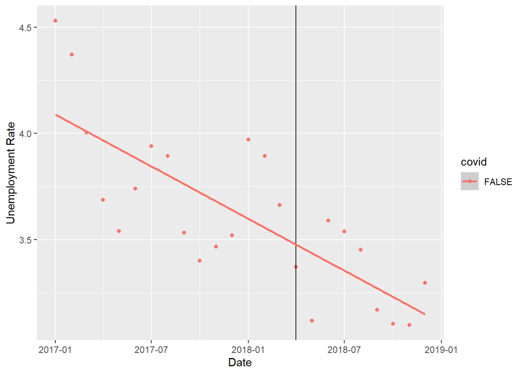

```r
linear_graph7 <- data_test %>%
  ggplot(aes(x = date, y = urate, col = covid)) +
  geom_point() +
  geom_vline(xintercept = ymd("2018-04-01")) +
  ylab("Unemployment Rate") +
  xlab("Date") +
  geom_smooth(aes(group = covid), method = 'lm', formula = y ~ x)
linear_graph7
```

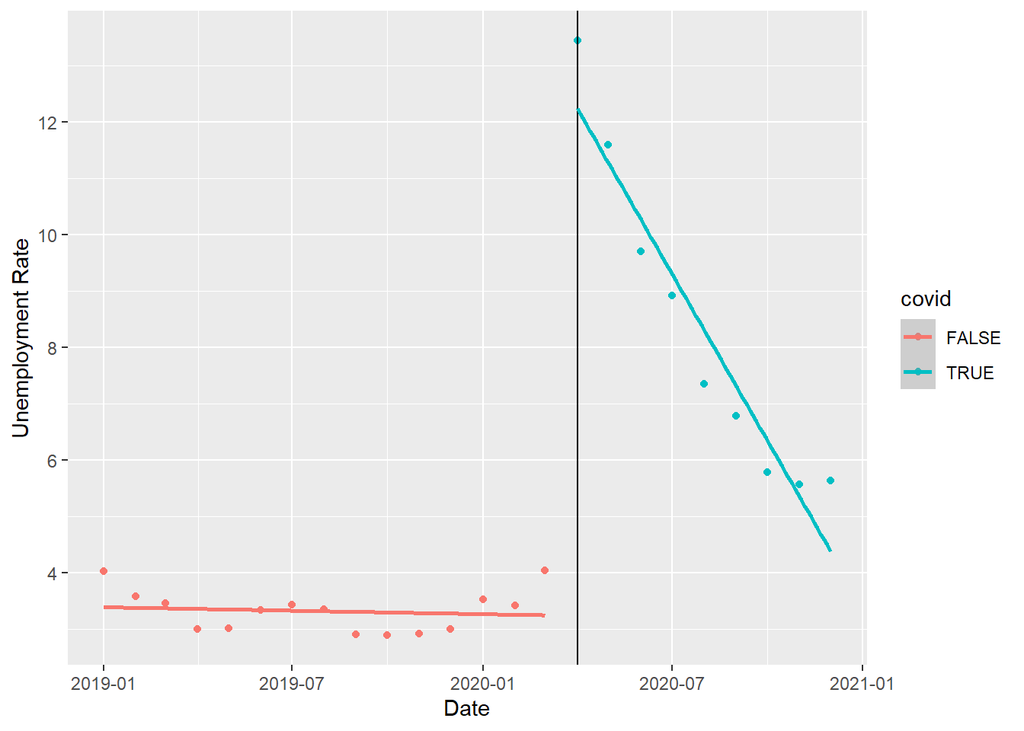

```r
linear_graph8 <- data_part6 %>%
  ggplot(aes(x = date, y = urate, col = covid)) +
  geom_point() +
  geom_vline(xintercept = ymd("2020-04-01")) +
  ylab("Unemployment Rate") +
  xlab("Date") +
  geom_smooth(aes(group = covid), method = 'lm', formula = y ~ x)
linear_graph8
```

Part 1: How has COVID affected the health of the retail industry, as measured by employment? The analysis looks at the unemployment rate before and after COVID19 allowing us to measure the health of the retail industry over the course of our time period. We first found that the unemployment rate before COVID19 was 3.24% in the retail industry. However, when looking at our data and the results we found, unemployment rose by 9.01% to a total of 12.25%. In the second model, we factored in polynomials and got a new unemployment rate of 4.02% and found that after covid the unemployment rate rose by 9.42% to a total of 13.44%. By looking at our graphs, you could see that the unemployment rate tapers off the further into covid we go. This shows that the retail industry is in the process of recovering but has not fully recovered yet as there are still covid restrictions in place.

Question 1 Linear Model:

```r
model1_part1 <- lm(urate ~ date_centered*covid + region, data = data_only_retail)
export_summs(model1_part1)
```

|  | Model 1 |
| --- | --- |
| (Intercept) | 3.24 *** |
|  | (0.01) |
| date_centered | -0.01 *** |
|  | (0.00) |
| covidTRUE | 9.01 *** |
|  | (0.01) |
| regionEastNorthCentralDivision | -0.02 *** |
|  | (0.01) |
| regionEastSouthCentralDivision | 0.00 |
|  | (0.01) |
| regionMiddleAtlanticDivision | -0.04 *** |
|  | (0.01) |
| regionMountainDivision | -0.01 * |
|  | (0.01) |
| regionNewEnglandDivision | -0.02 ** |
|  | (0.01) |
| regionSouthAtlanticDivision | -0.01 |
|  | (0.01) |
| regionWestNorthCentralDivision | -0.01 * |
|  | (0.01) |
| regionWestSouthCentralDivision | -0.01 |
|  | (0.01) |
| date_centered:covidTRUE | -0.97 *** |
|  | (0.00) |
| N | 139207 |
| R2 | 0.96 |
| *** p < 0.001; ** p < 0.01; * p < 0.05. |  |

Graph of Linear Model:

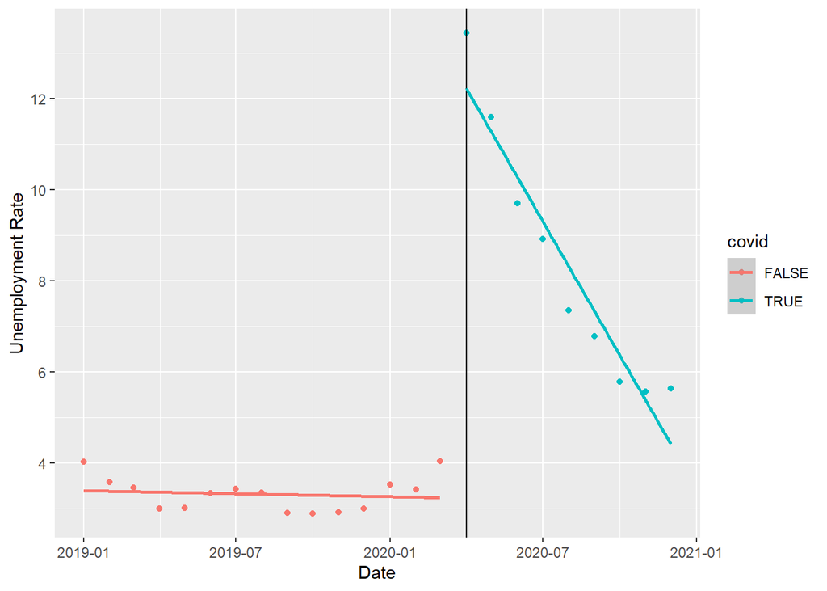

```r
linear_graph1 <- data_only_retail %>%
  ggplot(aes(x = date, y = urate, col = covid)) +
  geom_point() +
  geom_vline(xintercept = ymd("2020-04-01")) +
  ylab("Unemployment Rate") +
  xlab("Date") +
  geom_smooth(aes(group = covid), method = 'lm', formula = y ~ x)
linear_graph1
```

Question 1 Polynomial Model:

```r
model2_part1 <- lm(urate ~ date_centered*covid + I(date_centered^2)*covid + region, data = data_only_retail)
export_summs(model2_part1)
```

|  | Model 1 |
| --- | --- |
| (Intercept) | 4.02 *** |
|  | (0.00) |
| date_centered | 0.26 *** |
|  | (0.00) |
| covidTRUE | 9.42 *** |
|  | (0.00) |
| I(date_centered^2) | 0.02 *** |
|  | (0.00) |
| regionEastNorthCentralDivision | 0.00 |
|  | (0.00) |
| regionEastSouthCentralDivision | 0.00 |
|  | (0.00) |
| regionMiddleAtlanticDivision | 0.00 |
|  | (0.00) |
| regionMountainDivision | 0.00 |
|  | (0.00) |
| regionNewEnglandDivision | 0.00 |
|  | (0.00) |
| regionSouthAtlanticDivision | 0.00 |
|  | (0.00) |
| regionWestNorthCentralDivision | 0.00 |
|  | (0.00) |
| regionWestSouthCentralDivision | 0.00 * |
|  | (0.00) |
| date_centered:covidTRUE | -2.27 *** |
|  | (0.00) |
| covidTRUE:I(date_centered^2) | 0.11 *** |
|  | (0.00) |
| N | 139207 |
| R2 | 0.99 |
| *** p < 0.001; ** p < 0.01; * p < 0.05. |  |

Graph of Polynomial Model:

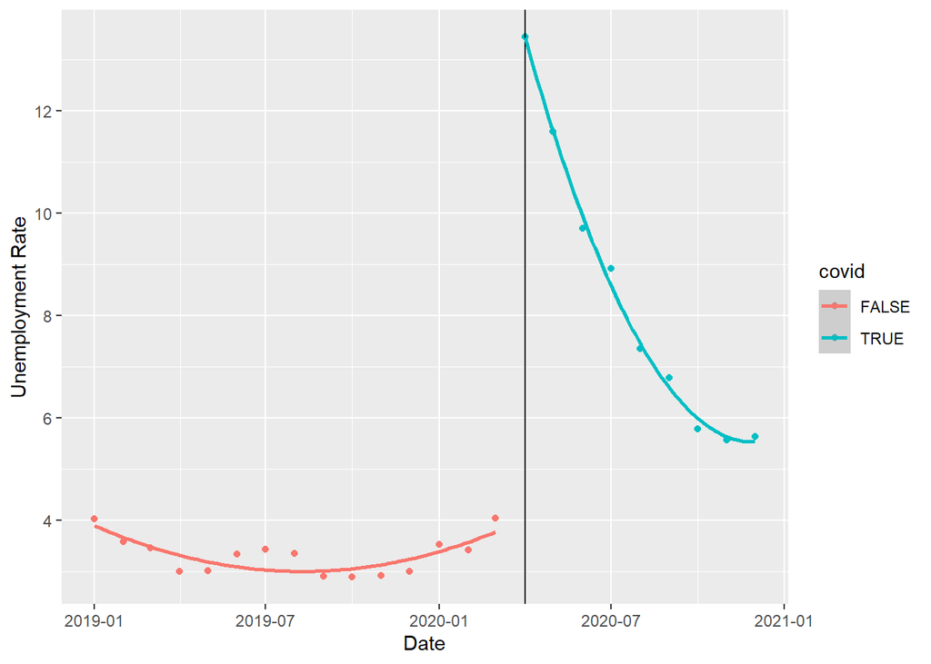

```r
poly_graph1 <- data_only_retail %>%
  ggplot(aes(x = date, y = urate, col = covid)) +
  geom_point() +
  ylab("Unemployment Rate") +
  xlab("Date") +
  geom_vline(xintercept = ymd("2020-04-01")) +
  geom_smooth(aes(group = covid), method = 'lm', formula = y ~ poly(x, 2))
poly_graph1
```

Part 2: How has retail fared relative to other industries?